# 住宅生産

岩田真一郎（神奈川大学経済学部）

2026-03-28作成，2026-03-28改訂

［PDF形式：334KB］

[都市内の住宅立地](https://shinichiro-iwata.github.io/lecture-notes-urban-econ/residential-location-choice.html)では，中心地から離れるほど，消費者が需要する敷地面積（住宅面積）は大きくなることを学びました．それでは，消費者が居住する建物の高さは，中心地からの距離とどのような関係にあるのでしょうか？そこで，実際のデータを用いて，その関係を見てましょう．

ここでは，[東京都オープンカタログサイト](https://portal.data.metro.tokyo.lg.jp/)の[土地利用現況調査GISデータ](https://catalog.data.metro.tokyo.lg.jp/dataset/t000008d2000000019)に収録されている「土地利用現況調査 令和3年区部（シェープファイル）」を用います．「土地利用現況調査」は，「土地利用現況」と「建物現況」の2つに分かれており，「建物現況」に23区内の建物の位置情報や高さが記録されています．建物には住宅のほか，工場や事務所，教育文化施設，厚生医療施設，商業施設などあらゆる用途が含まれるため，まず住宅のみを抽出しました．次に，建物の高さのばらつきに着目するため，共同住宅（データ上の分類では集合住宅）のみを対象としました．[^1]図1は[箱ひげ図](https://ja.wikipedia.org/wiki/%E7%AE%B1%E3%81%B2%E3%81%92%E5%9B%B3)を用いて，東京駅からの距離を3kmごとに区分し，共同住宅の高さを示しています．X印の横の数字は平均の高さを示しており，東京駅を中心地と考えた場合，そこから離れるにつれて低くなる傾向が見られます．

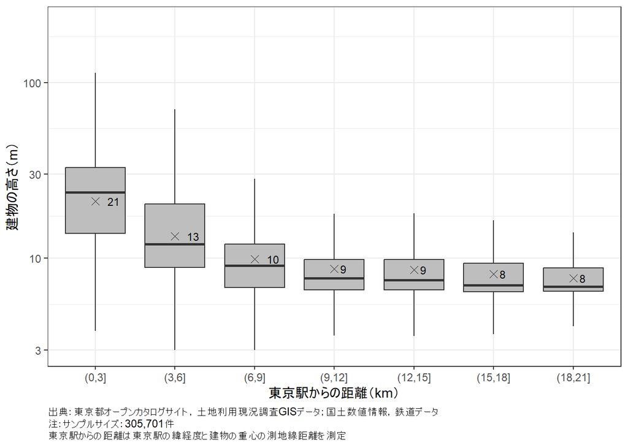

図1：箱ひげ図を用いた東京駅からの距離と23区内共同住宅の高さの関係

中心地では建物が高く，中心地から離れると建物が低くなることは直感的に理解されますが，ここではミクロ経済学の知識を応用してこの現象の説明を試みます．ただし，[都市内の住宅立地](https://shinichiro-iwata.github.io/lecture-notes-urban-econ/residential-location-choice.html)で中心的であった消費者の視点とは異なり，住宅メーカーや不動産デベロッパーといった企業の視点から考えます．

# 1 等量曲線

住宅メーカーや不動産デベロッパーといった企業は，土地，労働，建材といった**生産要素**を投入して住宅サービスを供給します．ここでは簡単化のため，住宅サービスを住宅面積Fで測ることにし，住宅面積は土地面積lと建物の高さnのみから生産されるとします．[^2]また，住宅は土地面積一杯（建ぺい率100％）に生産されると仮定します．このとき，住宅面積は土地面積が大きくなるほど，また建物が高くなるほど増加します．

ここで，企業が一定の住宅面積F<sub>0</sub>を供給目標として設定したとしましょう．この面積を確保するには，土地面積と建物の高さをどのように組み合わせればよいでしょうか．これを考えるために，図2に**等量曲線**F<sub>0</sub>とF<sub>1</sub>を示しています．等量曲線とは，同じ生産量を生む生産要素の組み合わせを示す曲線です．[^3]ここでは，同じ住宅面積を生む土地面積と建物の高さの組み合わせを示す曲線になります．

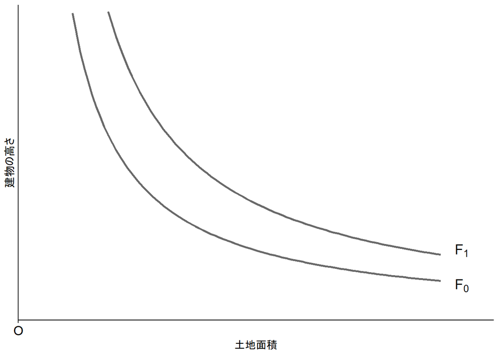

図2：等量曲線

等量曲線F<sub>0</sub>は，住宅面積がF<sub>0</sub>となる生産要素の組み合わせを表します．いま，F<sub>0</sub>上の任意の点から，土地面積の投入量を増加させ，建物の高さを変えないとします．このとき，当初の生産要素の組み合わせと比べて，土地面積が増えた後の組み合わせでは，仮定により住宅面積が大きくなります．このような組み合わせは，例えばより右側（あるいは上側，右上側）の等量曲線F<sub>1</sub>上に位置します．したがって，右側に位置する等量曲線ほど，大きな住宅面積に対応します．このことは，土地面積を増やしたときに，住宅面積を一定に保つためには，建物の高さを低くする必要があることを示しています．これが，等量曲線が右下がりとなる理由です．

# 2 費用最小化

それでは，等量曲線上のどのような生産要素の組み合わせで住宅面積F<sub>0</sub>を達成するのが望ましいでしょうか．合理的な企業であれば，できるだけ費用を抑えて目標を達成できる組み合わせを選ぶはずです．これを**費用最小化**とよびます．

企業の費用Cはどのように決まるのでしょうか．企業は生産要素の利用に対して費用を支払います．ここで，土地を1単位広くするための地代をR，建物を1単位高くするための建材価格を1とすると，企業の費用は（$\ref{C}$）式のように表されます．

$$\mathrm{C}=\mathrm{Rl}+\mathrm{n} \label{C}\tag{1}$$

（$\ref{C}$）式において，C，rが与えられると，費用を一定に保つ生産要素の組み合わせを求めることできます．（$\ref{C}$）式を，nについて解くと，（$\ref{n}$）式を得ます．

$$\mathrm{n=-Rl+C} \label{n}\tag{2}$$
図3は図2に（$\ref{n}$）式を満たす右下がりの直線を加えた図です．この右下がりの直線上は費用が一定に保たれるため，**等費用線**とよばれます．（$\ref{n}$）式から，等費用曲線の傾きは地代に–1を掛けた値に等しくなります．このため，等費用線は右下がりになります．これは，土地面積を1単位増やすと，費用を一定に保つために建物を低くする必要があることを反映しています．縦軸の切片はCになるため，切片が高いほど費用が高いことを意味します．図3には，異なる等費用線が3本引かれていますが，いずれも地代はRで一定です．一方，費用はC<sub>1</sub>が最も高く，C<sub>0</sub>，C<sub>2</sub>が続きます．

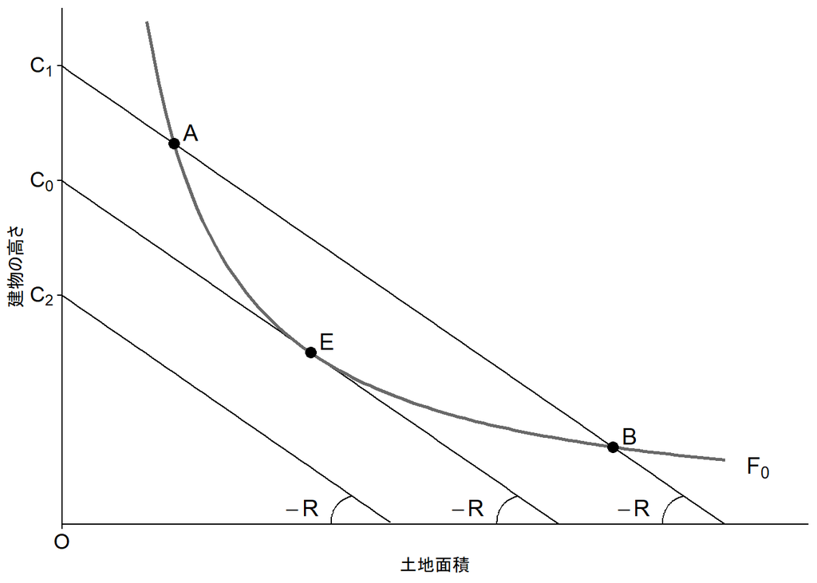

図3：等費用線と企業の費用最小化

3本の等費用線の中では，C<sub>2</sub>が最も低いですが，この等費用線上のどの生産要素の組み合わせでも住宅の広さF<sub>0</sub>を達成できません．すなわち，費用が低すぎます．一方，C<sub>1</sub>を費やすと，A点とB点の生産要素の組み合わせでF<sub>0</sub>を達成できます．しかし，企業はさらに費用を引き下げてF<sub>0</sub>を生産できます．これは，等量曲線F<sub>0</sub>上で，できるだけ左に位置する（切片の低い）等費用線を選択することを意味します．このとき，費用最小化を目指す企業の費用はC<sub>0</sub>となります．そして，生産要素の組み合わせは，等量曲線と等費用線が接するE点（**接点**）で決まります．[^4]

# 3 地代と建物の高さ

図1で見たように，建物の高さが中心地からの距離に対して低下するのは，企業が販売する住宅サービスの価格と関係しています．[^5]住宅サービスは住宅面積だけで測っているため，ここでいう価格は住宅面積1単位あたりの価格です．[都市内の住宅立地](https://shinichiro-iwata.github.io/lecture-notes-urban-econ/residential-location-choice.html)で考察したように，消費者は中心地に近いほど交通費を節約できるため，高い支払い許容額を持ちます．このため企業は，中心地付近では郊外に比べて高い住宅価格を設定できます．さらに，この高い住宅価格に対応して，中心地付近の土地利用に対して郊外よりも高い地代を支払うことも可能になります．[^6]

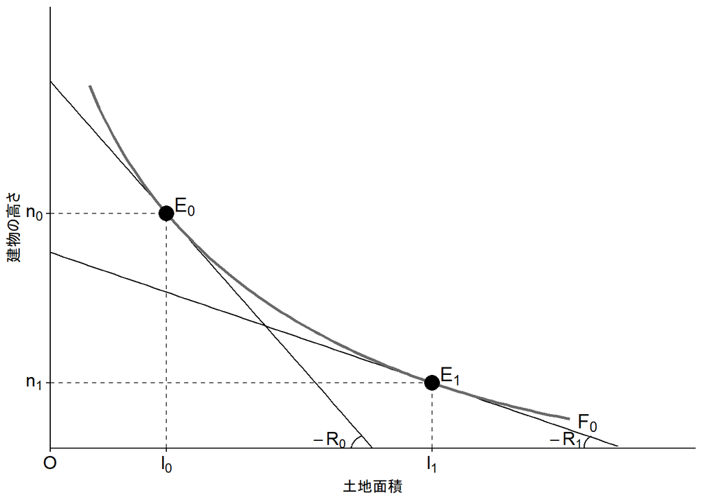

図4：中心地からの距離と生産要素の組み合わせ

そこで，図4は，異なる2地点における生産要素の組み合わせの違いを示しています．まず，郊外寄りのx<sub>1</sub>地点の地代をR<sub>1</sub>とします．このとき，企業はE<sub>1</sub>点で費用を最小化します．生産要素の組み合わせは（l<sub>1</sub>，n<sub>1</sub>）です．次に，中心地寄りのx<sub>0</sub>地点の地代をR<sub>0</sub>とします．先に述べたように，中心地寄りの地代は郊外寄りの地代よりも高くなります．この結果，等費用曲線の傾きが絶対値でみて大きくなり，費用最小点はE<sub>0</sub>点に移動します．生産要素の組み合わせは（l<sub>0</sub>，n<sub>0</sub>）になります．

改めて，生産要素の組み合わせの違いを見てみましょう．地代の低い郊外寄りのx<sub>1</sub>地点では，建物は低いですが，土地を大きく使い，住宅面積F<sub>0</sub>を確保しています．一方，地代の高い中心地寄りのx<sub>0</sub>地点では，大きな土地を使わず，建物は高くして住宅面積F<sub>0</sub>を確保しています．以上から，中心地から離れるに従い，建物の高さが低下することを説明できました．

# 4 テキストガイド

本稿では，企業の費用最小化と利潤最大化を組み合わせながら，中心地からの距離と建物の高さの関係について説明しました．次の洋書テキストの第2章にも同様の説明があります．

- Brueckner, Jan K.（2011）[“Lectures on Urban Economics”](https://mitpress.mit.edu/9780262016360/lectures-on-urban-economics/)，MIT Press

本稿では，住宅サービスの生産関数は明示的に示しませんでした．この点を紹介したテキストとして以下があります．

- 金本良嗣・藤原徹（2016）[『都市経済学（第2版）』](https://str.toyokeizai.net/books/9784492813034/)＜プログレッシブ経済学シリーズ＞東洋経済新報社

等量曲線の性質，企業の費用最小化や利潤最大化については，次の都市経済学のテキストに詳しく説明されています．

- 高橋孝明（2012）[『都市経済学』](http://www.yuhikaku.co.jp/books/detail/9784641184060)有斐閣ブックス

下記の補論では，23区内における低層住宅と高層住宅の混在について言及しています．このような様子を描いた建物や街並みの立体図やこのような現象が観察される歴史的経緯については以下が参考になります．

- ホルヘ・アルマザン＋Studiolab（2022）[『東京の創発的アーバニズム 横丁・雑居ビル・高架下建築・暗渠ストリート・低層密集地域』](https://book.gakugei-pub.co.jp/gakugei-book/9784761528300/)学芸出版社

# 補論：低層住宅と高層住宅の混在

本稿では，中心地から距離が離れるほど，建物の高さが低下することを説明しました．しかし，実際に東京の街並みを歩くと，中心地付近でも高層の共同住宅に混じって，低層の共同住宅が立地している様子が見られます．この理由としては，都心でも用途地域によって共同住宅を高層化できない場所があること，既存の低層共同住宅の中に権利関係の制約により建て替えが進まない場合があることなどが考えられます．

実は，この都心部の混在は，冒頭で紹介した図1の箱ひげ図からも読み取れます．箱ひげ図は，灰色の**箱**と箱から垂直に伸びる**ひげ**から構成されます．箱は建物の高さを順に並べたときの中央50％（第1四分位から第3四分位）に含まれる観測値の範囲を示し，箱の中の横線は中央値（建物の高さを順に並べたときの真ん中の値）を示します．ひげは，[外れ値](https://ja.wikipedia.org/wiki/%E5%A4%96%E3%82%8C%E5%80%A4)を除いた範囲での最小値と最大値を示します．

図1を見ると，東京駅に近いほど箱の大きさが大きく，ひげも長く伸びています．これは，東京駅に近いところでは様々な高さの建物が混在していること，すなわち，高層共同住宅を中心に，超高層共同住宅（タワーマンション）や低層共同住宅も立地していることを示しています．一方，23区の外縁部に向かうにつれて，ばらつきが小さく，中低層共同住宅でまとまっている様子が見られます．

# 補論：商業施設

本稿は共同住宅の生産要素の組み合わせに注目しましたが，商業施設についても同様の傾向が見られます．すなわち，駅前などの中心部の商業施設は，地代の高さを反映して，土地面積が小さく建物が高い多層型ですが，郊外の商業施設は，地代の低さを反映して，土地面積が大きく建物が低い低層（1～2階）型です．

このように郊外の商業施設は地代が安いため，土地面積が大きくなりますが，土地面積一杯に建物を建てることはまれです．むしろ，土地の一部を広大な駐車場として整備することが一般的です．モータリゼーションが進展した地方都市では駐車場の確保が重要となるため，このように土地の一部を駐車場として用いる形が選択されやすくなります．

# R環境

**セッション情報**

- R version 4.5.2
  - RStudio 2026.01.0+392
  - rmarkdown 2.30

**使用したパッケージ**

- `tidyverse`，`sf`，`geosphere`

# リンク

[都市経済学講義ノート](https://shinichiro-iwata.github.io/lecture-notes-urban-econ/)

[Rによる地理空間データの可視化](https://shinichiro-iwata.github.io/geospatial-data-visualization/)

[Shinichiro Iwata](https://shinichiro-iwata.github.io/)

**アイコン**

Font Awesome 7.0.0

**生成AIの使用について**

ChatGPTのサービスを利用した後，内容を確認し，必要に応じて編集を行いました．

[^1]: さらに，共同住宅には物置や自転車置き場なども含まれていたため，それらに該当する記載のある建物を除外しました．あわせて，3m以上（1階相当）の建物に限定しました．
[^2]: 住宅サービスは住宅面積のみで測れるものではなく，複数の属性から構成されます．この点は[住宅価格の推定](https://shinichiro-iwata.github.io/lecture-notes-urban-econ/hedonic-model.html)を参照ください．
[^3]: 等量曲線は**等生産量曲線**ともよばれます．
[^4]: 等量曲線の傾きは，曲線上の任意の点に接線を引き，その傾きを測ることで求められます．E点において，この等量曲線の傾きと等費用線の傾きは等しくなります．等量曲線の傾きの絶対値は**技術的限界代替率**とよばれ，等費用線の傾きの絶対値は**生産要素の相対価格**（要素価格比）とよばれます．したがって，E点では技術的限界代替率と生産要素の相対価格が等しくなります．なお，本稿では，建物の建材価格を1と仮定しているため，生産要素の相対価格は地代Rに等しくなります．
[^5]: ここでは時間の概念を考慮していないため家賃と考えても問題ありません．
[^6]: これは，利潤最大化を目指す企業が，土地の**限界生産物価値**と地代が等しくなるように土地を需要することに対応しています．詳しくは[店舗立地と商品価格](https://shinichiro-iwata.github.io/lecture-notes-urban-econ/downtown-restaurants.html)を参照ください．そこでは，この関係を用いて，財を高い価格で販売できる場所ほど，地代が高くなることを説明しています．